# Variation in the Southern Ocean Food Web

Jonathan J. Borrelli

# Initial Set-up

Load required libraries:

```r
require(igraph)
require(NetIndices)
require(reshape2)
require(ggplot2)
require(devtools)
require(vegan)
require(data.table)
```

Source code for functions to describe web properties

```r
url <- "https://raw.githubusercontent.com/jjborrelli/Ecological-Networks/master/FoodWebs/Rscripts/web_functions.R"
source_url(url)
```

Load in the data

```r
s.ocean <- read.csv("http://esapubs.org/archive/ecol/E092/097/diet.csv")
```

# Functions

```r
webPROPS <- function(graph){
  adj <- get.adjacency(graph, sparse = F)
  gind <- GenInd(adj)
  diam <- diameter(graph)
  avpath <- average.path.length(graph)
  cluster <- transitivity(graph)
  cannibals <- sum(diag(adj))

  degrees <- degree(graph, mode = "all")
  indegrees <- degree(graph, mode = "in")
  outdegrees <- degree(graph, mode = "out")

  numBas <- length(indegrees[which(indegrees == 0)])
  numTop <- length(outdegrees[which(outdegrees == 0)])
  basal <- (numBas/gind$N) * 100
  top <- (numTop/gind$N) * 100
  int <- ((gind$N - (numBas + numTop))/gind$N) * 100

  web.props <- data.frame(N = gind$N, L = gind$Ltot, LD = gind$LD, C = gind$C, D = diam,
             AvgPath = avpath, ClCoef = cluster, Can = cannibals, Bas = basal, Top = top, Int = int)
  return(web.props)
}
```

```r
permutes_rc <- function(mat, iter = 100){

  pattern1 <- matrix(c(0,1,1,0), nrow = 2, ncol = 2)
  pattern2 <- matrix(c(1,0,0,1), nrow = 2, ncol = 2)
  count <- 0

  mat.list <- list()

  while(count < iter){
    srow <- sample(1:nrow(mat), 2)
    scol <- sample(1:ncol(mat), 2)

    test <- mat[srow, scol]

    if(sum(test == pattern1) == 4){
      count <- count + 1
      mat[srow, scol] <- pattern2
      mat.list[[count]] <- mat

      next
    } else if(sum(test == pattern2) == 4){
      count <- count + 1
      mat[srow, scol] <- pattern1
      mat.list[[count]] <- mat

      next
    } else {next}
  }

  matrices <- lapply(mat.list, as.matrix)
  return(permuted.matrices = matrices)
}
```

# Southern Ocean Food Web

```r
el.df <- data.frame(pred = s.ocean$PREDATOR_NAME, prey = s.ocean$PREY_NAME)

SOgraph <- graph.edgelist(unique(as.matrix(el.df[,1:2])))

SOadjacency <- get.adjacency(SOgraph, sparse = F)
```

First take a quick look at what the food web looks like. Here I plot the web by trophic level by setting the layout (code shown below). Nodes are plotted with trophic position along the y-axis and plotted along the x-axis according to a random uniform distribution (`runif(x, 0, 1)`).

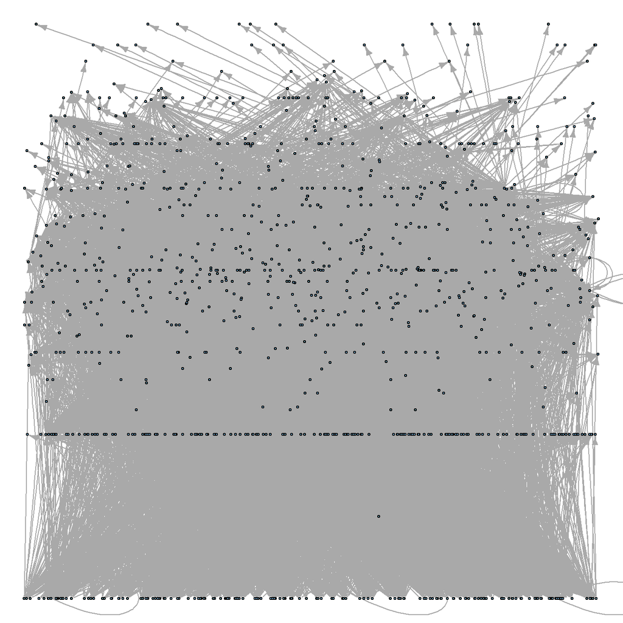

```r
par(mar = c(0,0,0,0))
layouts <- matrix(c(runif(gind$N), tind$TL), ncol = 2)
plot.igraph(SOgraph, layout = layouts, vertex.label = NA, edge.arrow.size = .5,
            vertex.size = 1)
```

## Web level properties

The `NetIndices` and `igraph` packages have functions to calculate a number of commonly used food web indices. The function `GenInd` from the `NetIndices` library easily calculates the number of nodes ($N$), total number of links ($L$), link density ($\frac{L}{N} = LD$), and connectance (along with some other indices that are not relevant to this dataset). Connectance in this case is calculated as: $C = \frac{L}{N*(N-1)}$

The `diameter` is the single longest path between two nodes. The `average.path.length` is the mean number of links between any two nodes in the web. The clustering coefficient (or `transitivity`) is the probability that the nearest neighbors of a given vertex are themselves connected. A high clustering coefficient is an indication that a network has “small world” properties. The sum of the diagonal elements of the adjacency matrix gives the number of species that are cannibalistic, with links that loop back to themselves.

```r
  diam <- diameter(SOgraph)
  avpath <- average.path.length(SOgraph)
  cluster <- transitivity(SOgraph)
  cannibals <- sum(diag(SOadjacency))

  degrees <- degree(SOgraph, mode = "all")
  indegrees <- degree(SOgraph, mode = "in")
  outdegrees <- degree(SOgraph, mode = "out")

  numBas <- length(indegrees[which(indegrees == 0)])
  numTop <- length(outdegrees[which(outdegrees == 0)])
  basal <- (numBas/gind$N) * 100
  top <- (numTop/gind$N) * 100
  int <- ((gind$N - (numBas + numTop))/gind$N) * 100

  web.props <- data.frame(N = gind$N, L = gind$Ltot, LD = gind$LD, C = gind$C, D = diam,
             AvgPath = avpath, ClCoef = cluster, Can = cannibals, Bas = basal, Top = top, Int = int)
```

```
     N     L    LD        C D AvgPath ClCoef Can  Bas   Top   Int
1 1095 10395 9.493 0.008677 6   2.114 0.1941  30 15.8 69.68 14.52
```

There are a total of 1095 species with 10395 interactions among them. The longest chain described in this food web is 6 but the average chain is 2.1144.

## Randomized properties

For this first randomization I will permute the prey of each species

```r
preys <- unique(el.df)$prey
el.df2 <- unique(el.df)
w.props <- list()
for(i in 1:100){
  perm <- sample(preys, replace = F)
  el.df2 <- cbind(el.df2, perm)

  new.df <- data.frame(el.df2$pred, perm)
  perm.g <- graph.edgelist(as.matrix(new.df))

  w.props[[i]] <- webPROPS(perm.g)
  print(i)
}
rbindlist(w.props)
```

[output not shown]

## 1990 to 2000

Here I cleave out the portion of the dataset that refers to observations with end dates between 1990 and 2000.

```r
so.ode <- as.character(s.ocean$OBSERVATION_DATE_END)
so.ode.split <- strsplit(so.ode, split = "/")

year <- c()
for(i in 1:length(so.ode.split)){
  year[i] <- so.ode.split[[i]][3]
}
s.ocean2 <- cbind(s.ocean, year)
so_90s <- s.ocean2[which(as.numeric(s.ocean2$year) >= 25 & as.numeric(s.ocean2$year) <= 35),]
so_90s <- droplevels(so_90s)
m2 <- split(so_90s, f = so_90s$year)
```

The `m2` object is a large list of data frames where each is a subset of the original Southern Ocean diet database consisting of observations from a given year in the range of 1990-2000.

I can convert these into annual food webs.

```r
year.g <- list()
for (i in 1:length(levels(so_90s$year))){

  el.df <- data.frame(pred = m2[[i]]$PREDATOR_NAME, prey = m2[[i]]$PREY_NAME)

  g <- graph.edgelist(unique(as.matrix(el.df[,1:2])))

  year.g[[i]] <- g
}
names(year.g) <- levels(so_90s$year)
```

Plot webs by year

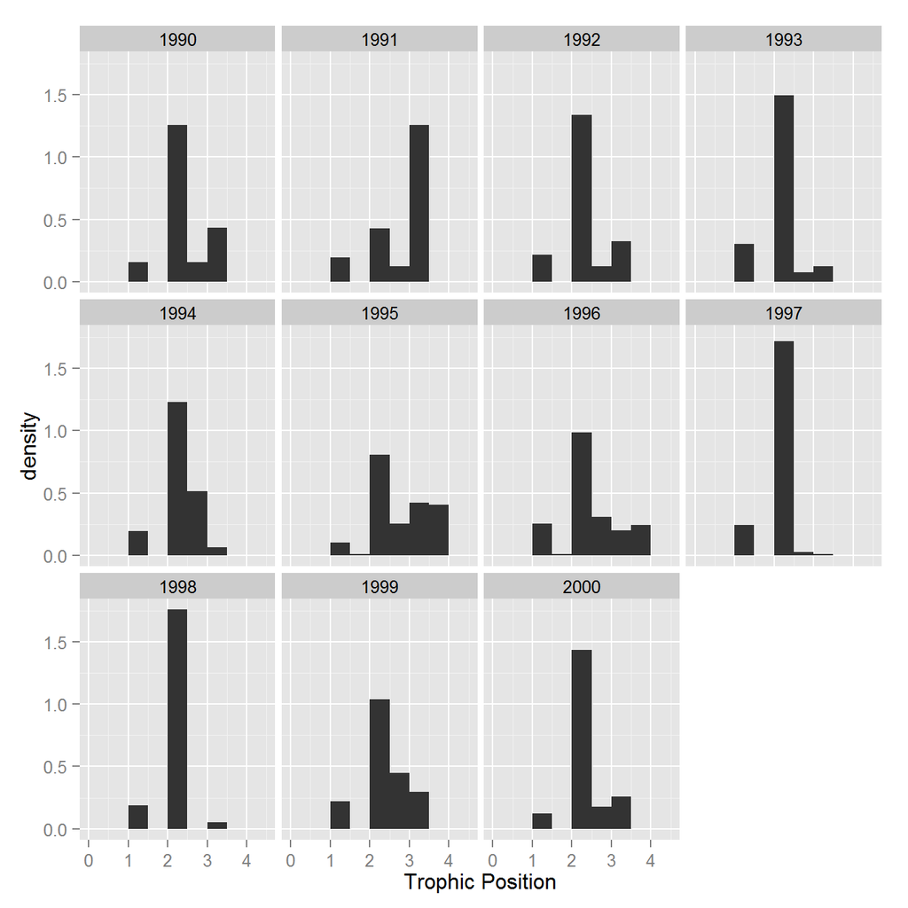

```r
y.ad <- lapply(year.g, get.adjacency, sparse = F)
y.tind <- lapply(y.ad, function(x){TrophInd(x)$TL})

myt <- melt(y.tind)
ggplot(myt, aes(x = value, y = ..density..)) + geom_histogram(binwidth = .5) + facet_wrap(~L1) + xlab("Trophic Position")
```

```r
y.lay <- list()
for(i in 1:length(y.tind)){
  y.lay[[i]] <- matrix(c(runif(length(y.tind[[i]])), y.tind[[i]]), ncol = 2)
}
```

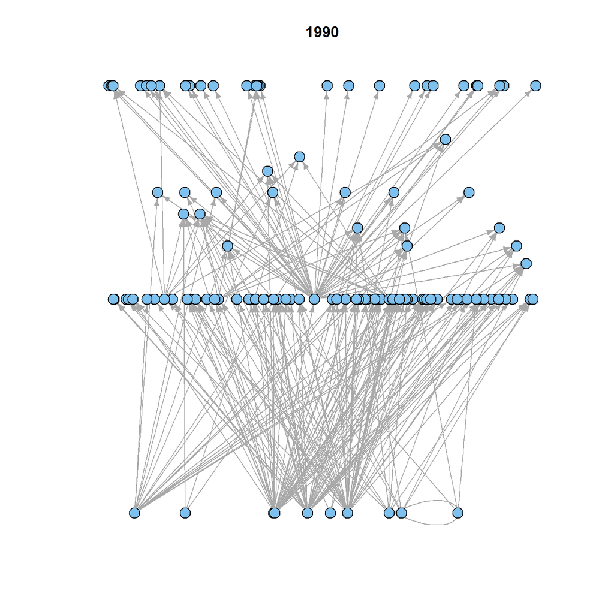

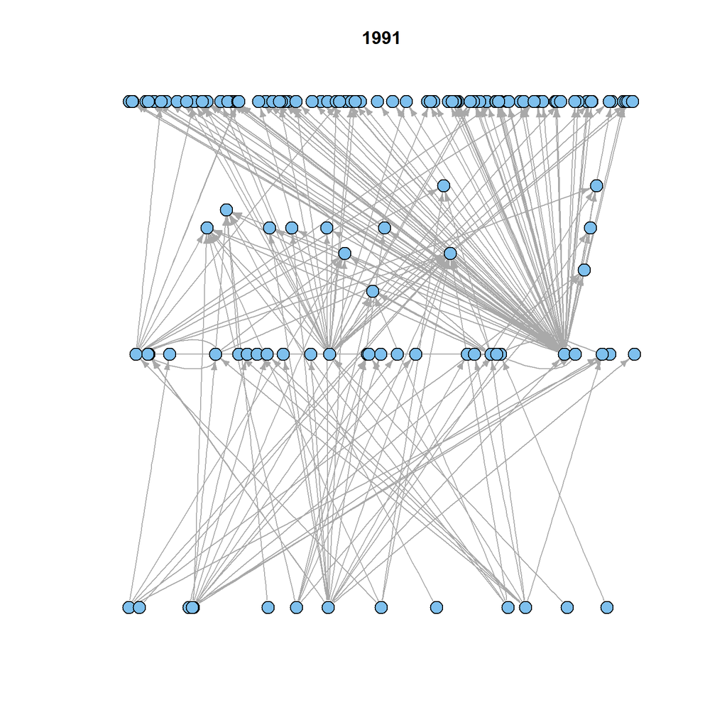

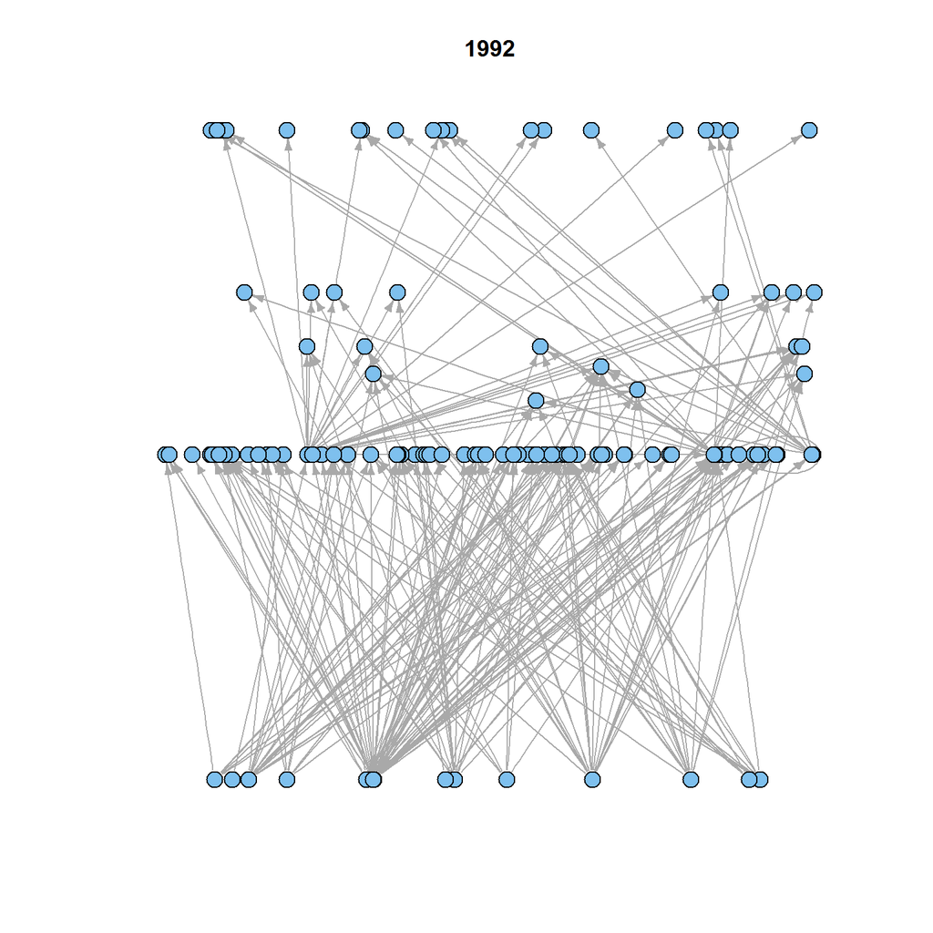

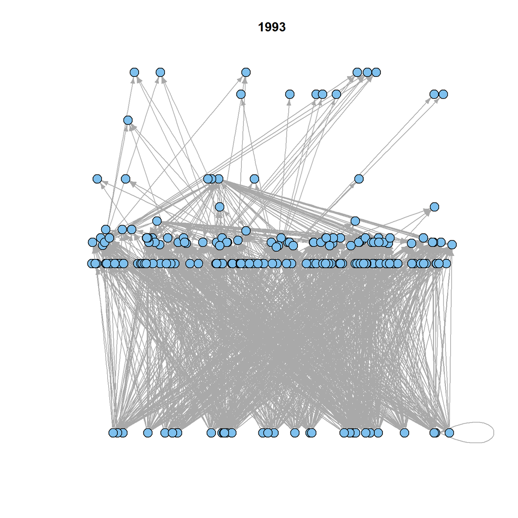

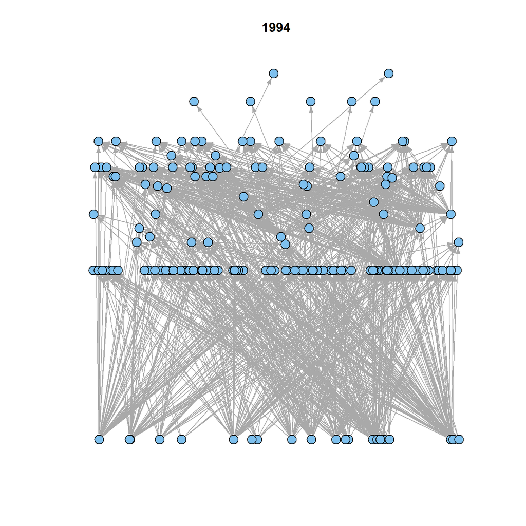

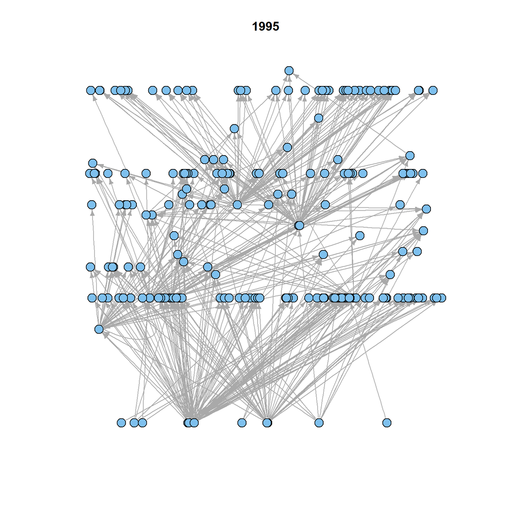

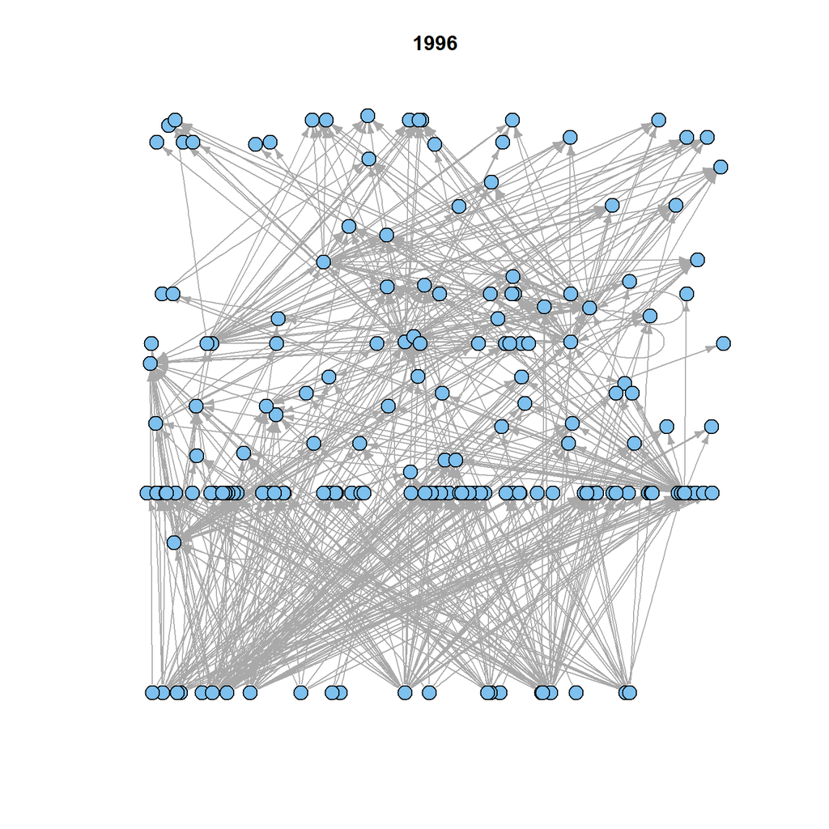

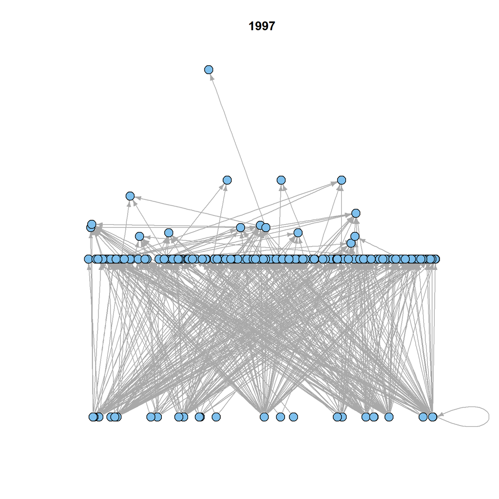

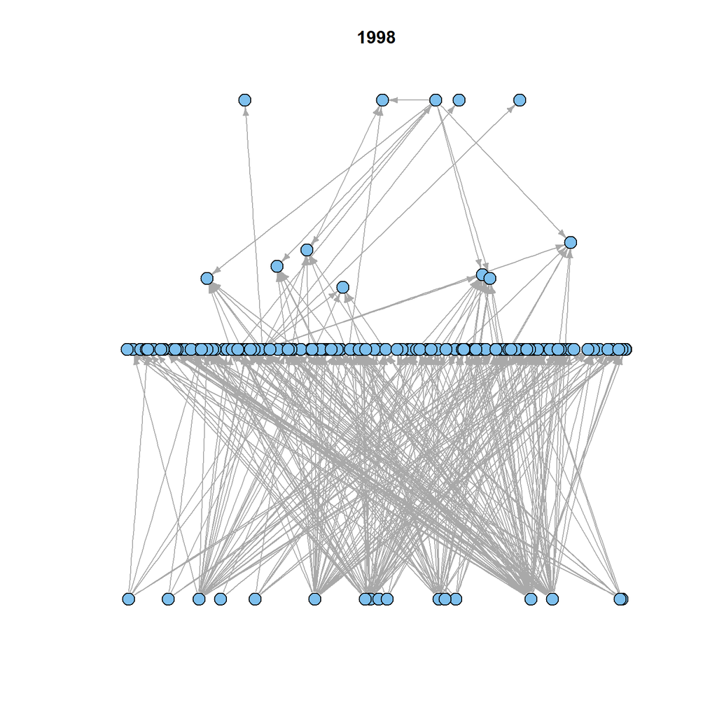

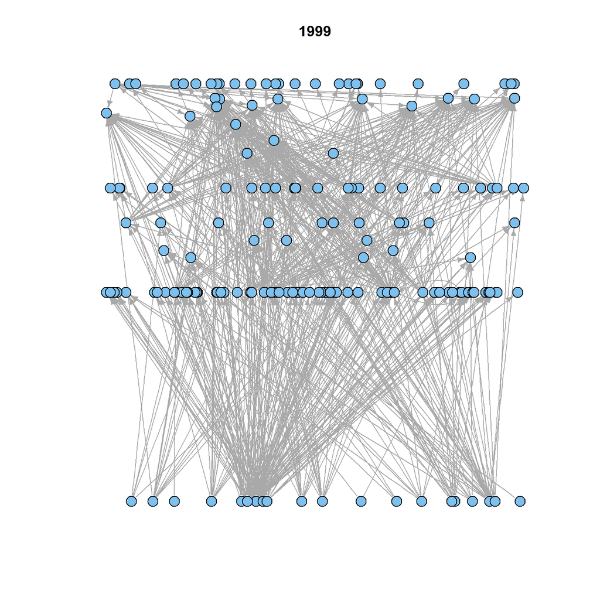

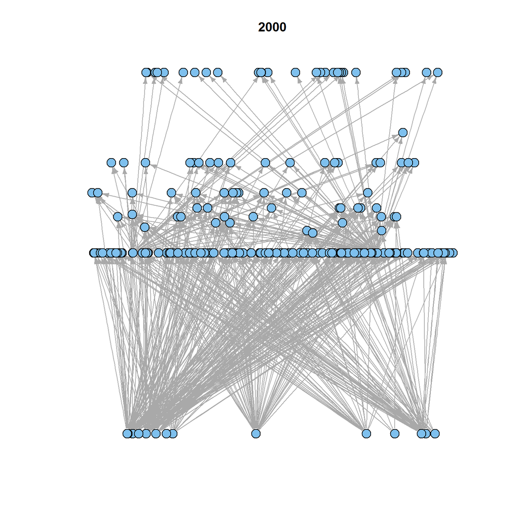

```r
for (i in 1:length(year.g)){
  plot.igraph(year.g[[i]], layout = y.lay[[i]], edge.arrow.size = .5, vertex.label = NA,
              vertex.size = 5, margin = 0, main = levels(so_90s$year)[i])
  #text(0, 0, label = levels(so_90s$year)[i], cex = 2)
}
```

```r
year.props <- sapply(year.g, webPROPS)

year.props
```

```
        1990     1991    1992    1993      1994    1995    1996    1997
N       129      145     130     205       215     213     189     205
L       224      185     210     1230      878     382     530     422
LD      1.736    1.276   1.615   6         4.084   1.793   2.804   2.059
C       0.01357  0.00886 0.01252 0.02941   0.01908 0.00846 0.01492 0.01009
D       2        3       3       4         3       3       4       3
AvgPath 1.189    1.464   1.29    1.336     1.421   1.799   1.656   1.099
ClCoef  0.002443 0.01329 0.01867 0.0006669 0.01798 0.01495 0.1238  0.00328
Can     1        2       1       1         0       1       5       1
Bas     6.977    9.655   10.77   14.63     9.767   5.164   12.7    11.71
Top     89.15    85.52   86.92   81.95     86.98   90.61   80.95   85.37
Int     3.876    4.828   2.308   3.415     3.256   4.225   6.349   2.927
        1998     1999    2000
N       181      183     222
L       298      599     464
LD      1.646    3.273   2.09
C       0.009147 0.01798 0.009457
D       3        3       2
AvgPath 1.107    1.29    1.241
ClCoef  0.005022 0.05054 0.019
Can     0        1       1
Bas     9.392    10.93   6.306
Top     88.95    78.69   92.34
Int     1.657    10.38   1.351
```

### By location

```r
loc.ls <- lapply(m2, function(x){split(x, f = x$LOCATION)})
t(rbindlist(lapply(loc.ls, function(x){lapply(x, nrow)})))
```

```
                                                           [,1] [,2] [,3]
                                                              0    0    0
Amery Basin                                                   0   23    0
Argentine Islands                                             0    0    0
Auster colony                                                 0    0    0
Bay of Morbihan, Kerguelen Islands                            0    0    0
Bird Island                                                   5   42   45
Bird Island, South Georgia. 54°30\031 S 37°00\031 W           0    6    6
Brothers Point                                                0    0    0
Bruny Island                                                  0    0    0
Canyon des Sourcils Noirs                                     0    0    0
Cap Noir, Iles Kerguelen                                      0    0    0
Cape Bird                                                     0    0    0
Cape Bird, Ross Island                                        0    0    0
Cape Crozier                                                  0    0    0
Cape Crozier, Ross Island                                     0    0    0
Cape Evans                                                    7    6    7
Cape Herschel                                                 0    0    0
Cape Hinode                                                   0   15    0
Cape Roget                                                    0    0    0
Cape Royds                                                    0    0    0
Cape Royds, Ross Island                                       0    0    0
Cape Shirreff                                                 0    0    0
Cape Washington                                               3    0   26
Charlotte Bay                                                 0    0   32
Cierva Point                                                  0    0    0
Commonwealth Bay                                              0    0    0
Coulman Island                                                0    0    0
Croker Passage                                                0    0   32
Crozet Islands                                                0    0    0
Deception Island                                              0    0    0
Diego Ramirez Islands                                         0    0    0
Doppler Hill                                                 16    0    0
Duthoit Point                                                 0    0    0
East Antarctica                                               0    0    0
Fortuna Bay                                                   0    8   31
Gourlay Peninsula                                             0    0    0
Harmony Point                                                 0    0    0
Heard Island                                                129    0   17
Heard Island, Macquarie Island                                0    0    0
```

[output cut: 349 more lines]

```
South Georgia. 54°30\031 S 37°00\031 W                         0     0
South Shetland Islands                                         0     0
Spit Bay                                                       0     0
St Helena Bay                                                  0     0
Stephenson Lagoon                                              0     0
Straits of Magellan                                            0     0
Stranger Point                                                 0    12
Svarthamaren                                                   0     0
Terra Nova Bay                                                 0     4
Tethys Bay                                                     4     0
Uchatka Point                                                  0     0
Vestfold Hills                                                 0     0
Vincennes Bay                                                  0     6
Volunteer Beach                                                0     0
Weddell Sea                                                    0     0
```

```r
m3 <- lapply(m2, droplevels)
loc.ls2 <- lapply(m3, function(x){split(x, f = x$LOCATION)})
loc.y.ls <- unlist(loc.ls2, recursive = F)


ly.g <- list()
for (i in 1:length(loc.y.ls)){

  el.df <- data.frame(pred = loc.y.ls[[i]]$PREDATOR_NAME, prey = loc.y.ls[[i]]$PREY_NAME)

  g <- graph.edgelist(unique(as.matrix(el.df[,1:2])))

  ly.g[[i]] <- g

}

ly.props <- sapply(ly.g, webPROPS)
ly.props
```

```
        [,1]   [,2]  [,3] [,4]    [,5]    [,6]  [,7]  [,8]   [,9] [,10]
N       6      8     4    17      42      9     47    10     2    18
L       5      7     3    16      41      9     80    17     1    17
LD      0.8333 0.875 0.75 0.9412  0.9762  1     1.702 1.7    0.5  0.9444
C       0.1667 0.125 0.25 0.05882 0.02381 0.125 0.037 0.1889 0.5  0.05556
D       1      1     1    1       1       1     1     1      1    1
AvgPath 1      1     1    1       1       1     1     1      1    1
ClCoef  0      0     0    0       0       0     0     0      NaN  0
Can     0      0     0    0       0       1     0     0      0    0
Bas     16.67  12.5  25   5.882   2.381   0     4.255 30     50   5.556
Top     83.33  87.5  75   94.12   97.62   88.89 95.74 70     50   94.44
Int     0      0     0    0       0       11.11 0     0      0    0
        [,11]   [,12] [,13]   [,14]   [,15]  [,16]  [,17]  [,18]  [,19]
N       41      5     17      32      7      7      16     9      16
L       40      4     22      31      6      6      15     8      15
LD      0.9756  0.8   1.294   0.9688  0.8571 0.8571 0.9375 0.8889 0.9375
C       0.02439 0.2   0.08088 0.03125 0.1429 0.1429 0.0625 0.1111 0.0625
D       1       1     2       1       1      1      1      1      1
AvgPath 1       1     1.16    1       1      1      1      1      1
ClCoef  0       0     0.1324  0       0      0      0      0      0
Can     0       0     1       0       0      0      0      0      0
Bas     2.439   20    41.18   9.375   14.29  14.29  6.25   11.11  6.25
Top     97.56   80    52.94   90.62   85.71  85.71  93.75  88.89  93.75
Int     0       0     5.882   0       0      0      0      0      0
        [,20]  [,21] [,22] [,23]  [,24]  [,25] [,26]   [,27]   [,28]
N       6      2     2     8      13     2     76      32      7
L       5      1     1     8      16     1     75      32      6
LD      0.8333 0.5   0.5   1      1.231  0.5   0.9868  1       0.8571
C       0.1667 0.5   0.5   0.1429 0.1026 0.5   0.01316 0.03226 0.1429
D       1      1     1     1      2      1     1       1       1
AvgPath 1      1     1     1      1.348  1     1       1       1
ClCoef  0      NaN   NaN   0      0.12   NaN   0       0       0
Can     0      0     0     1      1      0     0       0       0
Bas     16.67  50    50    0      7.692  50    1.316   9.375   14.29
Top     83.33  50    50    87.5   84.62  50    98.68   90.62   85.71
Int     0      0     0     12.5   7.692  0     0       0       0
        [,29] [,30]   [,31]  [,32]  [,33]   [,34]   [,35]   [,36]   [,37]
N       8     26      9      9      22      17      11      14      2
L       7     25      14     14     21      16      10      13      1
LD      0.875 0.9615  1.556  1.556  0.9545  0.9412  0.9091  0.9286  0.5
```

[output cut: 245 more lines]

```
Bas     3.571   33.33  3.704   3.704   2.632   3.03   7.692   3.704
Top     96.43   66.67  96.3    96.3    97.37   96.97  92.31   96.3
Int     0       0      0       0       0       0      0       0
        [,213] [,214]  [,215]  [,216] [,217]
N       7      44      13      6      7
L       6      45      12      4      6
LD      0.8571 1.023   0.9231  0.6667 0.8571
C       0.1429 0.02378 0.07692 0.1333 0.1429
D       1      1       1       1      1
AvgPath 1      1       1       1      1
ClCoef  0      0       0       0      0
Can     0      0       0       0      0
Bas     14.29  4.545   7.692   33.33  14.29
Top     85.71  95.45   92.31   66.67  85.71
Int     0      0       0       0      0
```